# easylabel

Myles Lewis, Katriona Goldmann

# 1 Introduction

A common problem in R is labelling scatter plots with large numbers of points and/or labels. We provide a utility for easy labelling of scatter plots and quick plotting of volcano plots and MA plots for gene expression analyses. Using an interactive shiny and plotly interface, users can hover over points to see where specific points are located and click on points to easily label them. Labels can be toggled on/off simply by clicking. An input box and batch input window provides an easy way to label points by name. Labels can be dragged around the plot to place them optimally. Notably we provide an easy way to export directly to PDF for publication.

# 2 Installation

Install from CRAN

```r
install.packages("easylabel")
library(easylabel)
```

Install from Github

```r
devtools::install_github("myles-lewis/easylabel")
library(easylabel)
```

If you wish to use the optional `useQ` argument with `easyVolcano()` and `easyMAplot()`, you will need to install additional package `qvalue` from Bioconductor:

```r
if (!requireNamespace("BiocManager", quietly = TRUE))
  install.packages("BiocManager")
BiocManager::install("qvalue")
```

If you wish to use the optional `fullGeneNames` argument, you will need to install packages `AnnotationDbi` and `org.Hs.eg.db` from Bioconductor:

```r
BiocManager::install("AnnotationDbi")
BiocManager::install("org.Hs.eg.db")
```

# 3 Scatter plots

Use `easylabel()` to open a shiny app and plot and label scatter plots. A table of the main data is supplied in the Table tab for easy viewing of data.

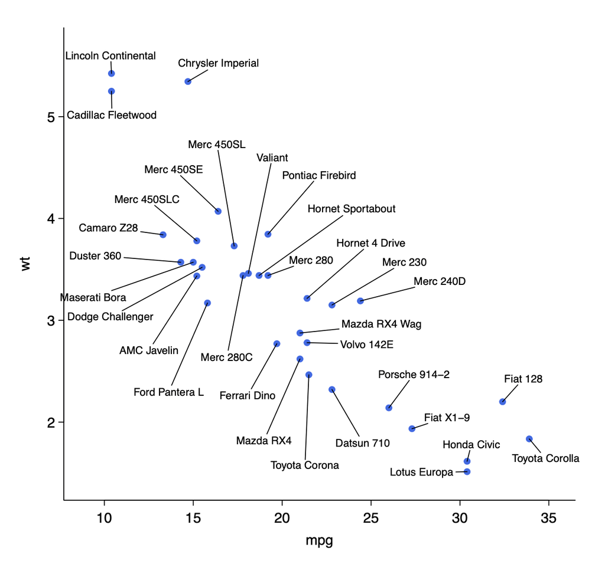

```r
data(mtcars)
easylabel(mtcars, x = 'mpg', y = 'wt',
          colScheme = 'royalblue')
```

## 3.1 Export plot to PDF

- Hover over and click on/off genes which you want to label.
- When you have selected all your chosen genes, then drag gene names to move label positions.
- Click the save button to export a PDF in base graphics.
- File type can be changed to export SVG, PNG, JPEG or TIFF.

If dealing with a plot with very large numbers of points (>20k), then it may make sense to rasterize the points by clicking the “Raster points” checkbox and setting a resolution (dpi). This can dramatically reduce file size for plots with millions of points, e.g. Manhattan plots. It also makes these pdf or svg images load much faster. Note that if you use pdf or svg when exporting, the axis lines, ticks, axis labels, label lines, label text etc are all preserved as vectors, only the points are rasterised, which is arguably the best of both worlds, and typically preferred by publications.

## 3.2 Save state

This button allows users to save the state of the plot including which points are labelled and the position of the labels. An rds file is saved in the working directory. This can be reloaded during another R session using the function `loadlabel()`. The original data can optionally be embedded in the saved rds file by ticking the “Embed data” checkbox. If the data is not embedded the function will need access to the original data object, so this must be loaded into the global environment before calling `loadlabel()`.

`loadlabel()` can refer directly to the rds file. Alternatively the rds file can be loaded into the global environment as an object and `loadlabel()` can be applied to this object.

## 3.3 Export SVG from plotly

- Switch to SVG when finalised (only do this at last moment as otherwise editing can very slow, particularly with large numbers of points).
- Press the camera button in the plotly modebar to save image as SVG.

## 3.4 Export as plotly object

The `output_shiny` option enables users to switch between invoking the shiny app or directly outputting a plotly object. For example, to extract a plotly figure with draggable annotations:

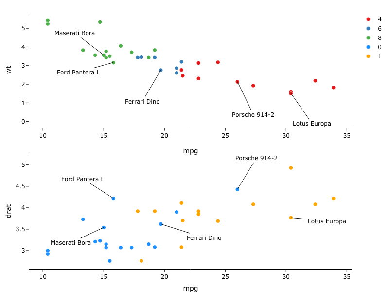

```r
data(mtcars)

p1 <- easylabel(mtcars, x = 'mpg', y = 'wt', col = 'cyl',
                startLabels = rownames(mtcars)[mtcars$gear == 5],
                output_shiny = FALSE) %>%
  layout(yaxis = list(zeroline = FALSE))

p2 <- easylabel(mtcars, x = 'mpg', y = 'drat', col = 'vs',
                colScheme = c("dodgerblue", "orange"),
                startLabels = rownames(mtcars)[mtcars$gear == 5],
                output_shiny = FALSE) %>%
  layout(xaxis = list(zeroline = FALSE))

plotly::subplot(p1, p2, nrows = 2, shareY = TRUE, titleX = TRUE, margin = 0.05)
```

Note that while the labels and lines can still be dragged and moved in the exported plotly object, clicking on points to add them, exporting to PDF and borders around label text, which are all shiny/ PDF output features, are not available from a pure plotly object.

Plotly objects can also be exported as a return value by pressing the ‘Export plotly & exit’ button in the shiny app. In this case the object retains the labelled points and their edited positions.

## 3.5 Colour

Similar to ggplot2 and plotly, colour can either be set as a single colour, using `colScheme = 'blue'` or can be set to change with the level of a factor variable within `data` by setting `col`. Transparency can be altered by setting `alpha`. Currently colour gradients are not supported.

```r
easylabel(mtcars, x = 'mpg', y = 'wt',
          col = 'cyl')
```

## 3.6 Shape

Marker shapes can either be set as a single shape using `shapeScheme = 21`, based on the base graphics `pch` symbol scheme (see `points()`), or shapes can be set to change with the level of a factor variable within `data` by setting `shape`. Shapes and colours can be combined.

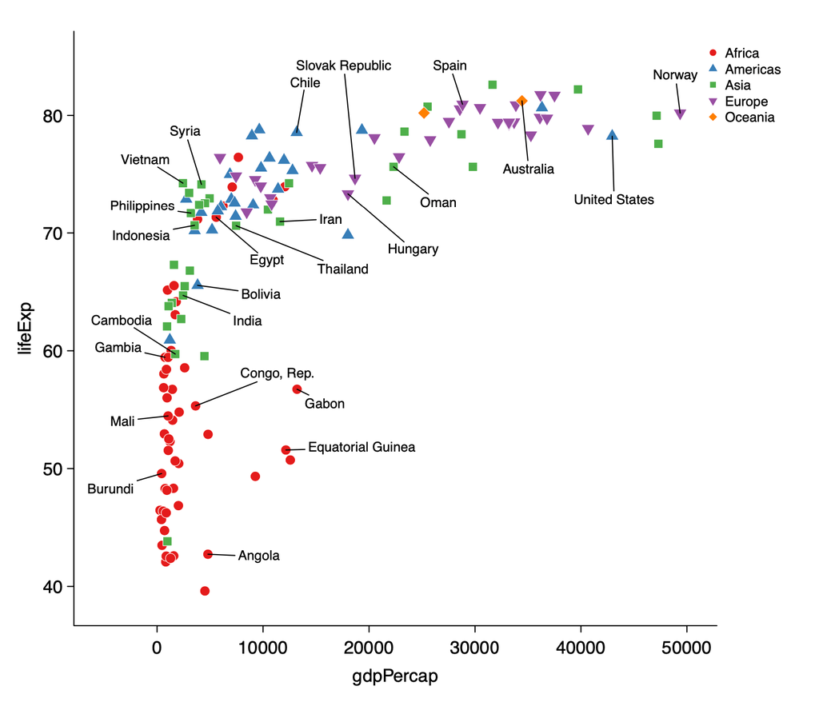

```r
# gapminder data set
if(!require(gapminder)) {install.packages("gapminder")}
library(gapminder)
easylabel(gapminder[gapminder$year == 2007, ], x = 'gdpPercap', y = 'lifeExp',
          col = 'continent', shape = 'continent',
          size = 10,
          labs = 'country',
          zeroline = FALSE)
```

## 3.7 Size

The size of all markers can be adjusted by setting `size` to a single number e.g. `size = 6` (default 8). Size can be assigned to a column of continuous data within `data` to produce a bubble chart. The size of points is automatically scaled to fit within a range of point sizes, determined by `scaleRange`.

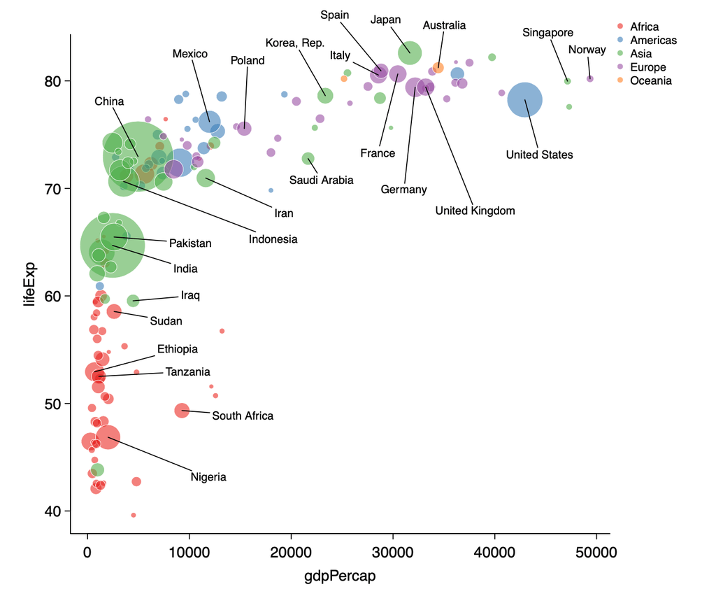

```r
library(gapminder)
easylabel(gapminder[gapminder$year == 2007, ], x = 'gdpPercap', y = 'lifeExp',
          col = 'continent', labs = 'country',
          size = 'pop',
          alpha = 0.6,
          zeroline = FALSE)
```

## 3.8 Choosing label names

By default, `easylabel()` takes the rownames of the main dataframe as the label names. Any column can be selected for label names by setting `labs` to the name of a column within `data`, as for example in the Gapminder dataset plots above.

## 3.9 Controlling axes

### 3.9.1 Axis titles

Axis titles can be set using `xlab` and `ylab`. These accept R expressions to allow maths symbols. This is primarily designed to work when exporting plots to PDF via base graphics, since plotly does not natively understand expressions.

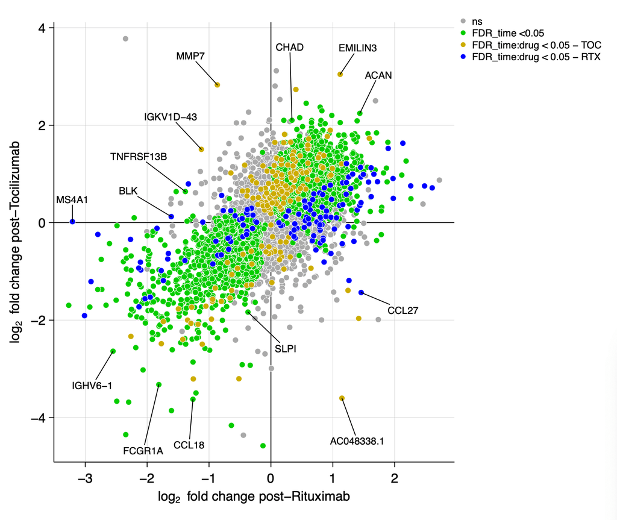

```r
easylabel(xymatrix, x = 'x', y = 'y', col = 'col',
          colScheme = c('darkgrey', 'green3', 'gold3', 'blue'),
          xlab = expression("log"[2] ~ " fold change post-Rituximab"),
          ylab = expression("log"[2] ~ " fold change post-Tocilizumab"),
          showgrid = TRUE)
```

### 3.9.2 Axis limits and outliers

`xlim` and `ylim` allow control over the range of each axis. Outlying points are shown as diamonds. Outliers can be toggled off using `showOutliers = FALSE`. Outlier symbol, colour and line width can be set using `outlier_shape`, `outlier_col` and `outlier_lwd` respectively.

### 3.9.3 Axis tick marks

Axis tick marks can be controlled by setting `xaxp` or `yaxp` to a vector of form `c(x1, x2, n)` where `x1` and `x2` are the limits of the tick marks and `n` is the number of intervals between tick marks.

For full customisation of axis tick coordinates and labels use `xticks` or `yticks`, which are specified as a list of two named vectors `at = ...` and `labels = ...`.

```r
# example axis ticks
if(!require(gapminder)) {install.packages("gapminder")}
library(gapminder)
easylabel(gapminder[gapminder$year == 2007, ], x = 'gdpPercap', y = 'lifeExp',
          col = 'continent', shape = 'continent',
          size = 10,
          labs = 'country',
          zeroline = FALSE,
          xaxp = c(0, 50000, 10),
          yaxp = c(40, 85, 9),
          showgrid = TRUE)
```

## 3.10 Gridlines

Gridlines can be shown by setting `showgrid = TRUE`. If `showgrid` is set to `"x"` or `"y"` then gridlines are shown only for that axis. Density of gridlines can be controlled by setting `xaxp` or `yaxp` (see Axis tick marks).

Black lines through the origin can be controlled by setting `zeroline` to `TRUE` or `FALSE`.

Dashed grey horizontal lines can be added at specific levels by setting `hline` with a vector of values. Similarly dashed grey vertical lines can be added by setting `vline` with a vector of values.

## 3.11 Legends

Setting `showLegend` to `TRUE` or `FALSE` can be used to show or hide the legend.

Legends can be positioned by setting `legendxy`. This gives a vector of coordinates for the position of the legend in plotly paper reference with `c(0, 0)` being the bottom left corner and `c(1, 1)` being the top right corner of the plot window.

Plotly has unusual behaviour in that the x coordinate always aligns the left side of the legend. However, the y coordinate aligns the top, middle or bottom of the legend dependent on whether it is in the top, middle or bottom 1/3 of the plot window. So `c(1, 0)` positions the legend in the bottom right corner outside the right margin of the plot, while `c(1, 0.5)` centre aligns the legend around the centre of y axis.

## 3.12 Further control of plotting

Further control of plotting can be achieved by passing other arguments to plot() via R’s `...` argument. For example, a box around the plot can be added using `bty = 'o'` (see `par()`).

## 3.13 panel.last

Base graphics’ `panel.last` argument is a flexible way to add plotting commands. This provides a way to add trend lines, loess lines or any additional features such as extra legends to the plot after the points are plotted, but before labels are drawn. Note that `panel.last` only works when saving to PDF, and is not available in plotly.

```r
# example adding a trend line using panel.last
fit <- lm(xymatrix$y ~ xymatrix$x)
easylabel(xymatrix, x = 'x', y = 'y', col = 'col',
          colScheme = c('darkgrey', 'green3', 'gold3', 'blue'),
          xlab = expression("log"[2] ~ " fold change post-Rituximab"),
          ylab = expression("log"[2] ~ " fold change post-Tocilizumab"),
          showgrid = TRUE, fullGeneNames = TRUE,
          panel.last = {
            abline(fit, col='red')
          })
```

# 4 Volcano plots

Use the `easyVolcano()` function to quickly plot a volcano plot from DESeq2 or EdgeR objects. The `useQ` argument will switch to using q values for FDR.

```r
# Example DESeq2 object
head(volc1)
```

```
##               baseMean log2FoldChange     lfcSE         stat     pvalue
## 5_8S_rRNA   0.01625099     0.02726923 2.9811510  0.009147217 0.99270168
## 5S_rRNA     3.66321881     0.05989097 0.4115732  0.145517159 0.88430257
## 7SK        12.96667458    -0.46156215 1.3668722 -0.337677614 0.73560615
## A1BG      290.75694559     0.23486554 0.3514587  0.668259368 0.50396804
## A1BG-AS1  170.77906789     0.11800652 0.2001594  0.589562618 0.55548392
## A1CF        4.56855647    -1.23495475 0.4855212 -2.543565265 0.01097276
##                padj
## 5_8S_rRNA        NA
## 5S_rRNA   0.9823854
## 7SK       0.9528927
## A1BG      0.8956205
## A1BG-AS1  0.9117136
## A1CF      0.4531638
```

```r
# Example limma object
head(volc2)
```

```
##               logFC  AveExpr         t      P.Value   adj.P.Val           B
## A1BG      0.7697662 6.389039  4.692064 0.0011239293 0.008610736 -1.16895727
## A1BG-AS1  0.5298897 3.610850  4.688657 0.0011293516 0.008638889 -0.85241114
## AAAS     -0.4162720 5.349529 -5.578986 0.0003398373 0.004148831  0.17585449
## AACS     -0.2049703 3.690271 -1.465073 0.1768461859 0.299064278 -5.88763988
## AAGAB     0.2970478 5.538436  5.446618 0.0004033869 0.004553688 -0.02478892
## AAK1      0.1969886 1.861988  1.286456 0.2302992497 0.362402197 -5.74356735
```

```r
# Typical DESeq2 workflow
volc1 <- results(dds)
easyVolcano(volc1, useQ = TRUE)
```

If you want to specify your own columns within the dataset set `x` to the column containing log fold change, `y` to the column containing raw p values and `padj` to the column containing adjusted p values. `labs` can be used to specify the column containing label names, otherwise this defaults to `rownames(data)`.

```r
# Manually specify columns
easyVolcano(volc1, x = 'log2FoldChange', y = 'pvalue', padj = 'padj')

# To use nominal unadjusted p value for significant genes
easyVolcano(volc1, x = 'log2FoldChange', y = 'pvalue')
```

Note that if you specify `y` for a column of p values but leave `padj` blank, the function assumes you are using nominal unadjusted p values for the cutoff for significance.

## 4.1 MA plots

Use the `easyMAplot()` function to quickly plot an MA plot from DESeq2 or EdgeR objects.

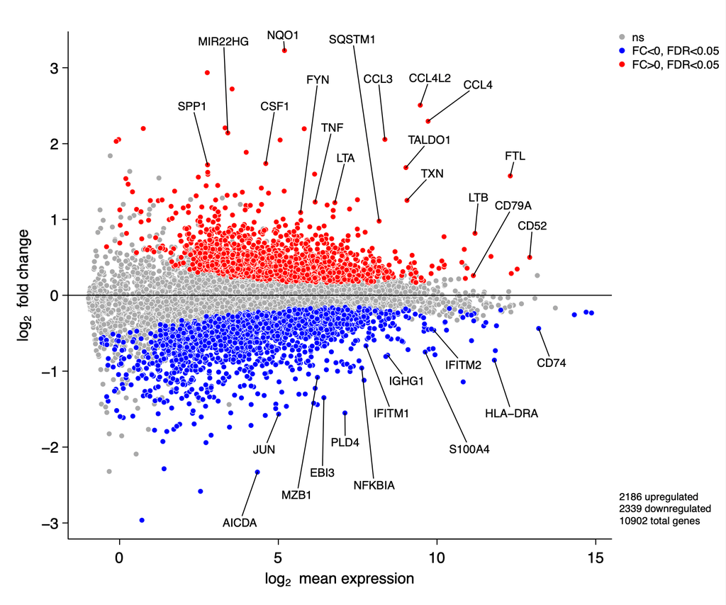

```r
easyMAplot(volc2, useQ = TRUE)
```

## 4.2 Expanding full gene names

The `fullGeneNames` argument will use Bioconductor package `AnnotationDbi` and the `org.Hs.eg.db` human gene database to expand gene symbols in the Table tab. Both will need to be installed from Bioconductor.

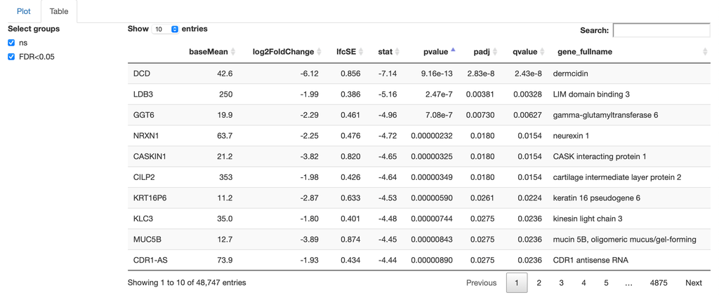

```r
BiocManager::install("AnnotationDbi")
BiocManager::install("org.Hs.eg.db")
easyVolcano(volc1, useQ = TRUE, fullGeneNames = TRUE)
```

Full gene names are also shown when hovering over points in the scatter plot, which can make it easier to label points of interest. For mouse genes, install `org.Mm.eg.db` and set `AnnotationDb = org.Mm.eg.db` (note the lack of quotes).

```r
BiocManager::install("org.Mm.eg.db")
library(org.Mm.eg.db)
easyVolcano(volc1,
            fullGeneNames = TRUE,
            AnnotationDb = org.Mm.eg.db)
```

## 4.3 Colour schemes

For volcano plots a simple colour scheme with downregulated genes in blue and upregulated genes in red can be rendered by setting `fccut = 0`.

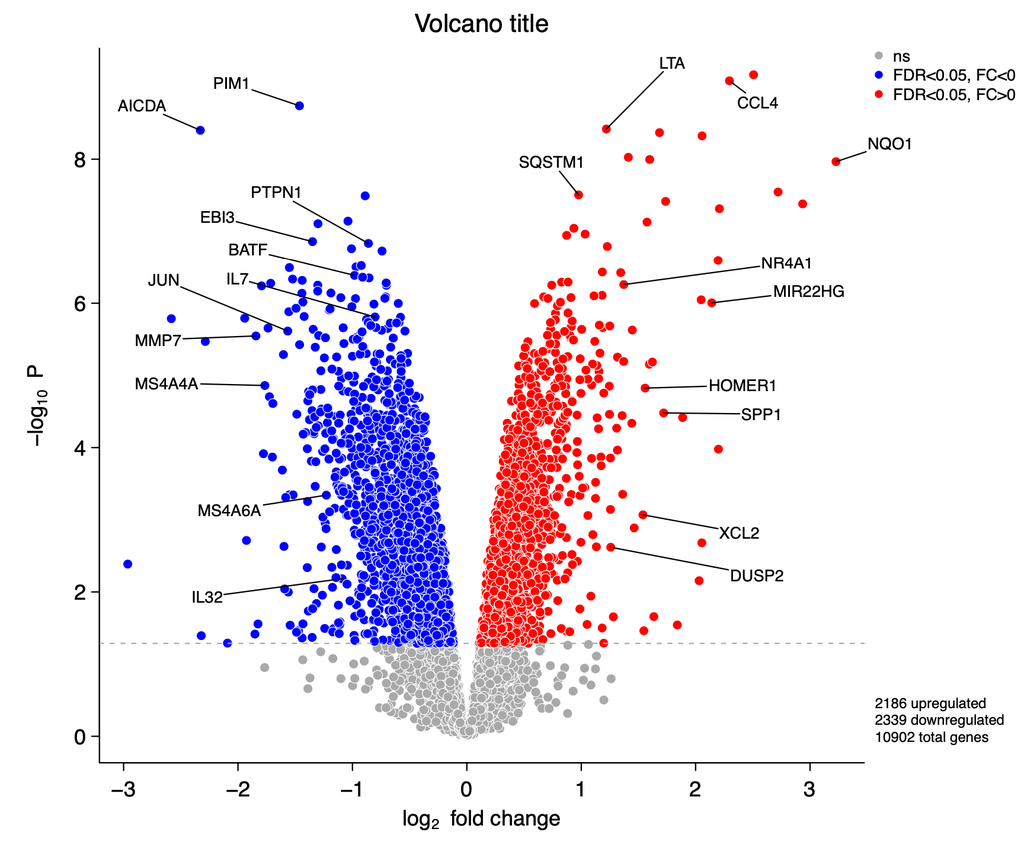

```r
easyVolcano(volc2,
            useQ = TRUE,
            fccut = 0,
            main = "Volcano title")
```

## 4.4 Titles

A title can be added using `main = "Title"`. The font size of the title can be modified using `cex.main = 2` (default 1.2) if saving to PDF.

## 4.5 Adding left/right subtitles

You can add left and right sided titles using `Ltitle` and `Rtitle` to explain the direction of effect for up/downregulation. The use of `expression` in the example below shows how to add left/right arrow symbols to the titles. The symbols only appear in the saved PDF - they are not compatible with plotly.

`LRtitle_side = 1` puts these titles on the bottom while `LRtitle_side = 3` puts them on the top.

`cex.lab` controls font size for these titles as well as axis titles. `cex.axis` controls font size for axis numbering.

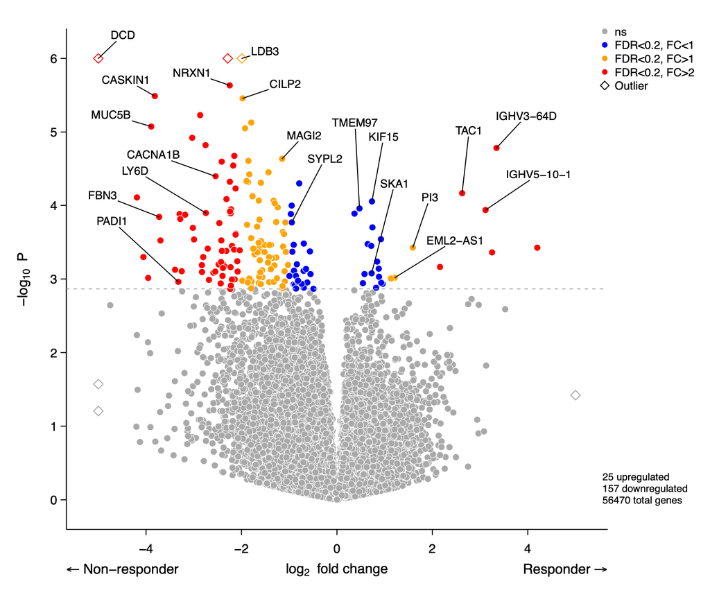

```r
easyVolcano(volc1,
            useQ = TRUE, fullGeneNames = TRUE,
            Ltitle = expression(symbol("\254") ~ "Non-responder"),
            Rtitle = expression("Responder" ~ symbol("\256")),
            LRtitle_side = 1,
            cex.lab = 0.9, cex.axis = 0.8,
            fccut = c(1, 2), fdrcutoff = 0.2,
            ylim = c(0, 6), xlim = c(-5, 5),
            colScheme = c('darkgrey', 'blue', 'orange', 'red'))
```

## 4.6 Setting P value cut-off

The FDR cutoff is set using `fdrcutoff` (volcano plots allow a single value, while MA plots allow multiple values). In order to force significant genes to be shown based on unadjusted P values, this can be achieved by a workaround setting both `y` and `padj` manually to the unadjusted p value column. Note this does mean the legend incorrectly states ‘FDR <’ etc.

```r
easyVolcano(volc1, y = 'pvalue', padj = 'pvalue', fdrcutoff = 0.01)
```

## 4.7 Axis limits and outliers

`xlim` and `ylim` allow control over the range of each axis. Outlying points are shown as diamonds (see example above). Outliers can be toggled off using `showOutliers = FALSE`. Outlier symbol, colour and line width can be set using `outlier_shape`, `outlier_col` and `outlier_lwd` respectively.

## 4.8 Complex colour schemes

The colour scheme system has been expanded to allow multiple fold change cut-offs. In the example above the colours are symmetrical.

In the next 2 plots, the colours range from blue for downregulated genes, through to red for upregulated genes. Vertical lines can be added using `vline`.

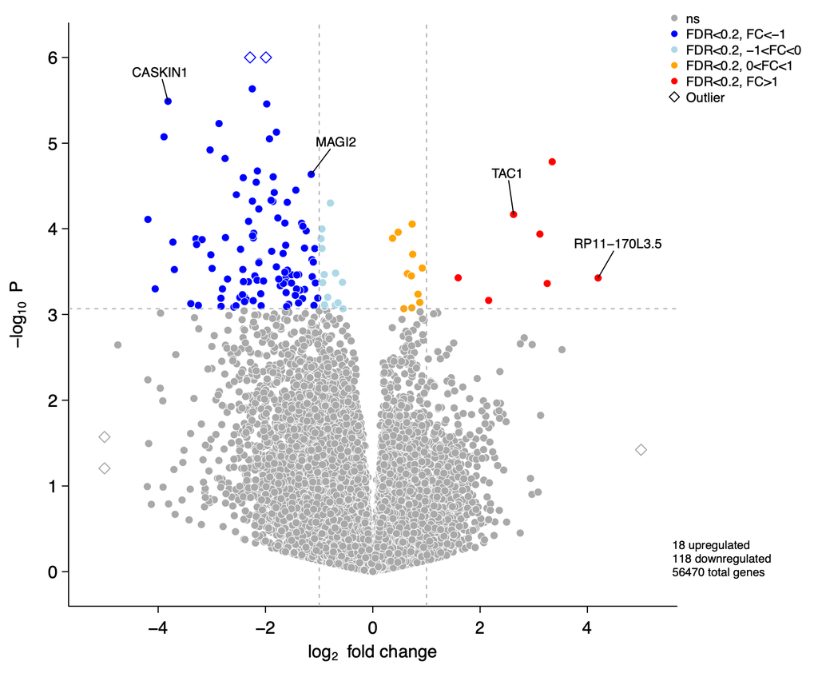

```r
colScheme <- c('darkgrey', 'blue', 'lightblue', 'orange', 'red')
easyVolcano(volc1, fccut = 1, fdrcutoff = 0.2,
            ylim = c(0, 6), xlim = c(-5, 5),
            colScheme = colScheme,
            vline = c(-1, 1))
```

The next example has 6 colours and also shows how to remove the white outlines around points using `outline_col = NA` and use transparency instead via `alpha`.

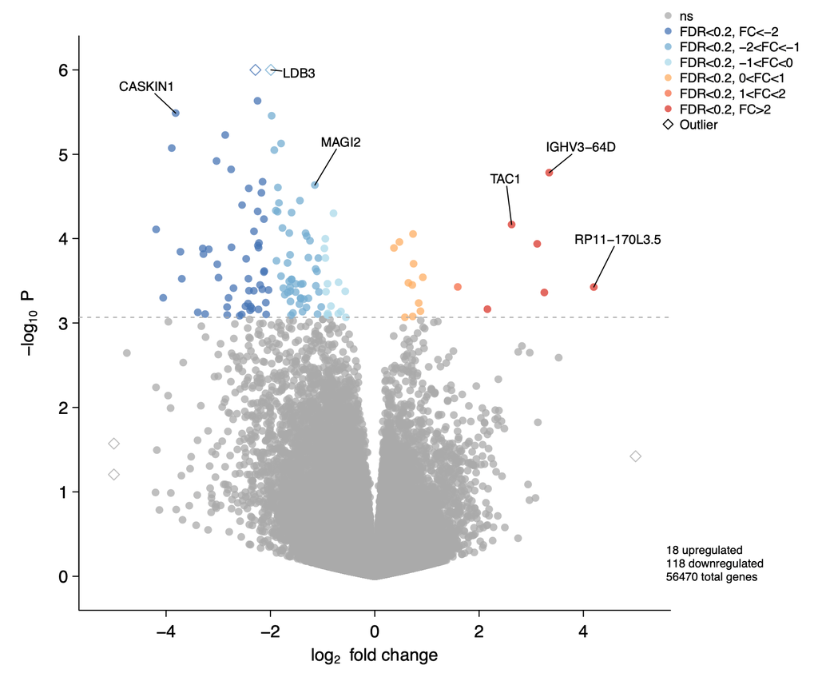

```r
library(RColorBrewer)
colScheme <- c('darkgrey', brewer.pal(9, 'RdYlBu')[c(9:7, 3:1)])
easyVolcano(volc1, fccut = c(1, 2), fdrcutoff = 0.2,
            ylim = c(0, 6), xlim = c(-5, 5),
            colScheme = colScheme,
            alpha = 0.75, outline_col = NA)
```

Similarly 6 colours can be applied to MA plots using 3 levels of cut-off for FDR (note the colour scheme is in a slightly different order).

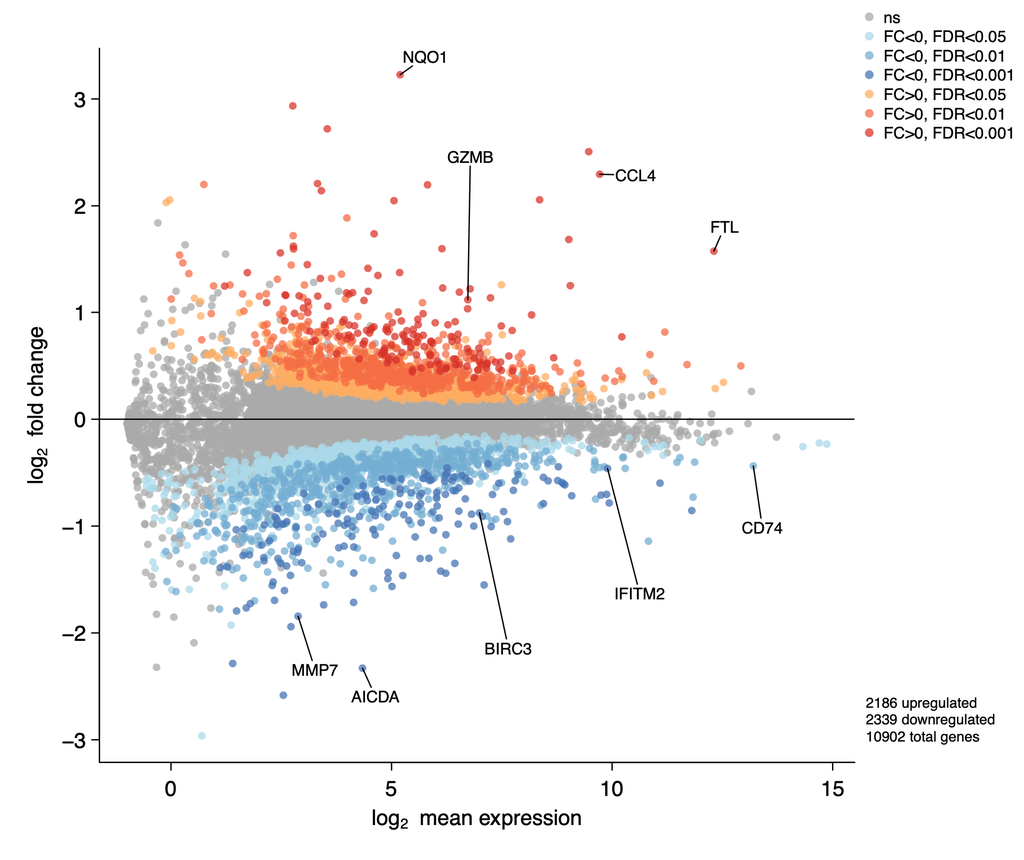

```r
colScheme <- c('darkgrey', brewer.pal(9, 'RdYlBu')[c(7:9, 3:1)])
easyMAplot(volc2, fdrcutoff = c(0.05, 0.01, 0.001), size = 6, useQ = TRUE,
           alpha = 0.75, outline_col = NA,
           colScheme = colScheme)
```

# 5 Controlling labels

Label lines can be altered using the argument `labelDir` or by selecting the Label direction pulldown menu in the shiny app. A couple of examples are shown below:

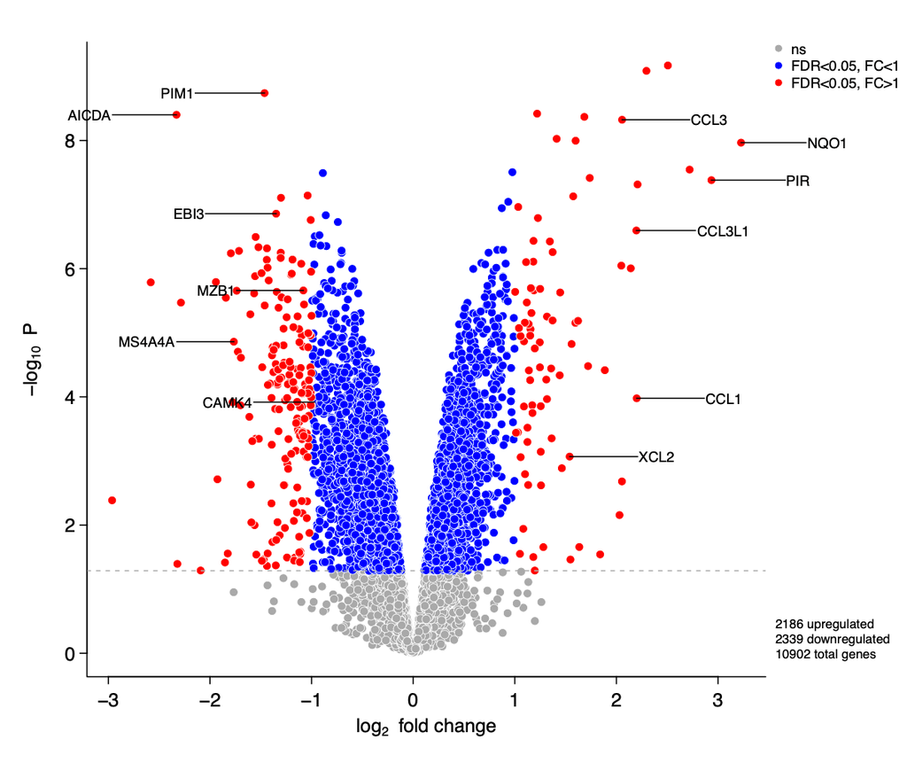

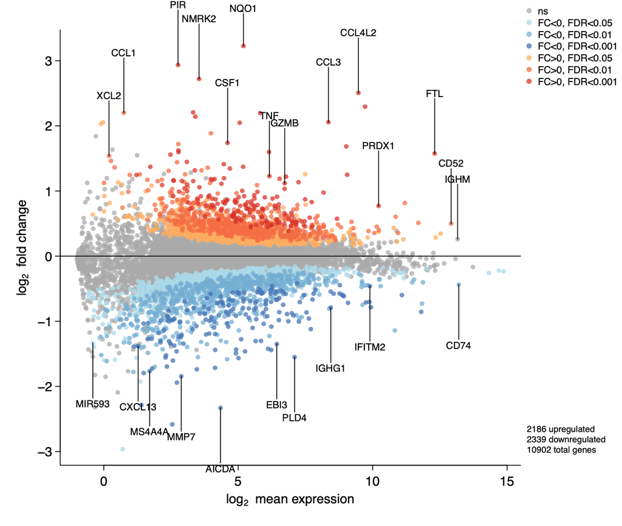

```r
easyVolcano(volc1, labelDir = "horiz")
easyMAplot(volc1, labelDir = "vert")
```

## 5.1 Label line and text

Label line colour can be set using `line_col`. Label text colour can be set using `text_col`. Each of these can be set to match the colour of each point by setting each to `"match"`. Default label line length can be altered by changing `lineLength` (default 75 in pixels). `cex.text` can be changed to alter the font size of labels (default 0.72).

## 5.2 Adding label boxes

Rectangles can be drawn around the label text, using `rectangles = TRUE`, and will appear when saving to PDF (they are not supported in plotly). Rectangle fill colour can be set using `rect_col` and rectangle border colour can be set using `border_col`. Use `border_col = NA` to turn off rectangle borders. The amount of padding in pixels around label text can be specified by setting `padding`. The amount of roundedness in pixels of rectangle corners is specified by `border_radius`.

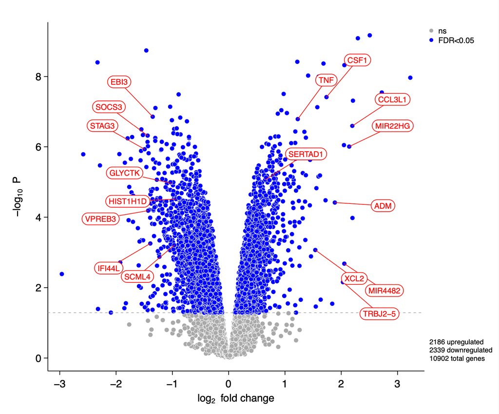

```r
# Simple outlines
easyVolcano(volc2, useQ = TRUE, fccut = 0,
            rectangles = TRUE)

# Red outlined labels, rounded ends
easyVolcano(volc2, useQ = TRUE, fullGeneNames = TRUE,
            rectangles = TRUE,
            padding = 5,
            border_radius = 10,
            line_col = 'red',
            border_col = 'red',
            text_col = 'red')
```

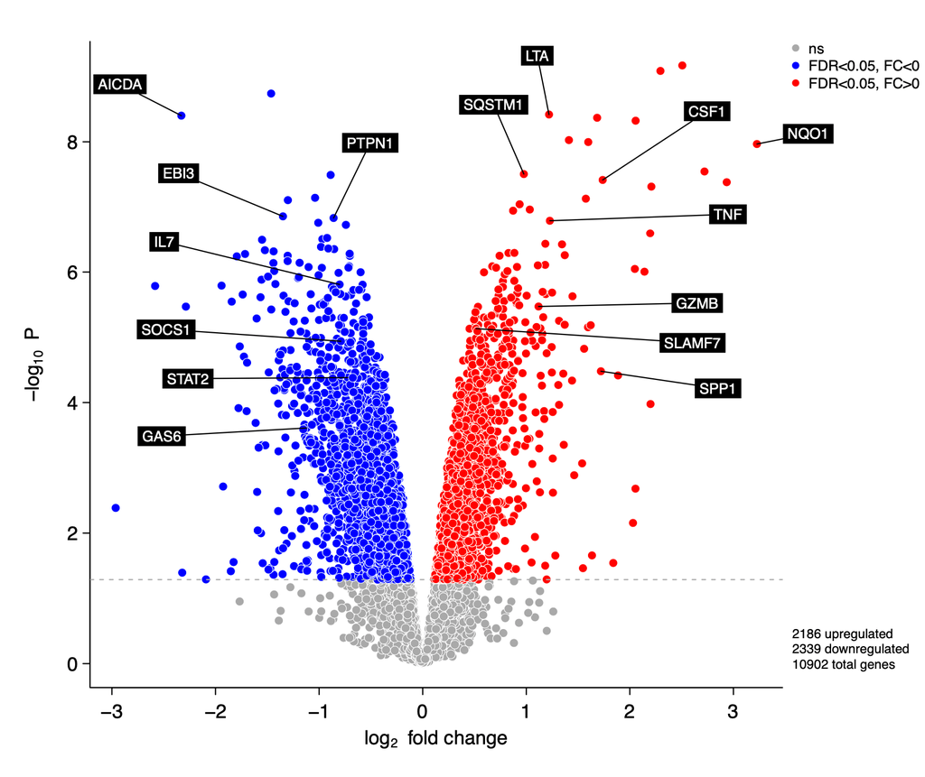

```r
# Transparent grey rectangles, rounded ends
easyMAplot(volc2, fdrcut = c(0.05, 0.01, 0.001), size = 6, useQ = TRUE,
           alpha = 0.75, outline_col = NA,
           fullGeneNames = TRUE,
           colScheme = c('darkgrey', brewer.pal(9, 'RdYlBu')[c(7:9, 3:1)]),
           rectangles = TRUE,
           border_col = NA,
           padding = 5,
           rect_col = adjustcolor('grey', alpha.f = 0.6),
           border_radius = 20)

# White text on black background, no rounding
easyVolcano(volc2, useQ = TRUE, fullGeneNames = TRUE,
            fccut = 0,
            rectangles = TRUE,
            padding = 4,
            border_radius = 0,
            rect_col = 'black',
            text_col = 'white',
            border_col = NA)
```

## 5.3 Matching label & point colours

While label text and label lines can be adjusted by setting `text_col` and `line_col` to individual colours, label text and label lines can also be set to mirror the colour of each point by setting `text_col = "match"` and `line_col = "match"` respectively. Label box fill colour or rectangle outline colour can also be set to match each point’s colour by setting `rect_col = "match"` or `border_col = "match"` (label boxes are not supported in plotly).

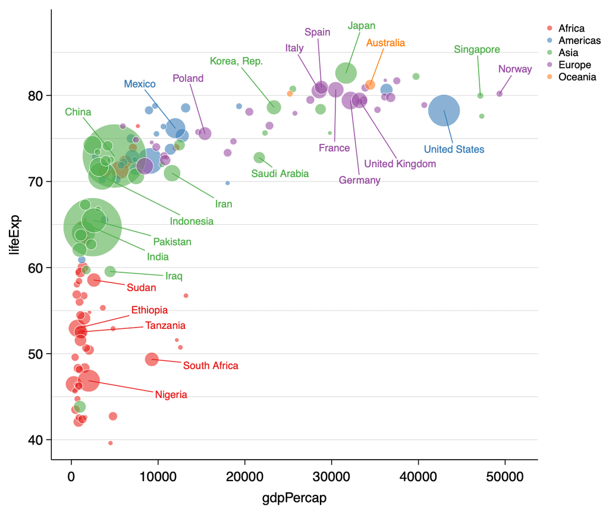

```r
# Label text and label lines match point colours
easylabel(gapminder[gapminder$year == 2007, ], x = 'gdpPercap', y = 'lifeExp',
          col = 'continent', labs = 'country',
          size = 'pop',
          alpha = 0.6,
          line_col = "match", text_col = "match",
          zeroline = FALSE, showgrid = "y")
```

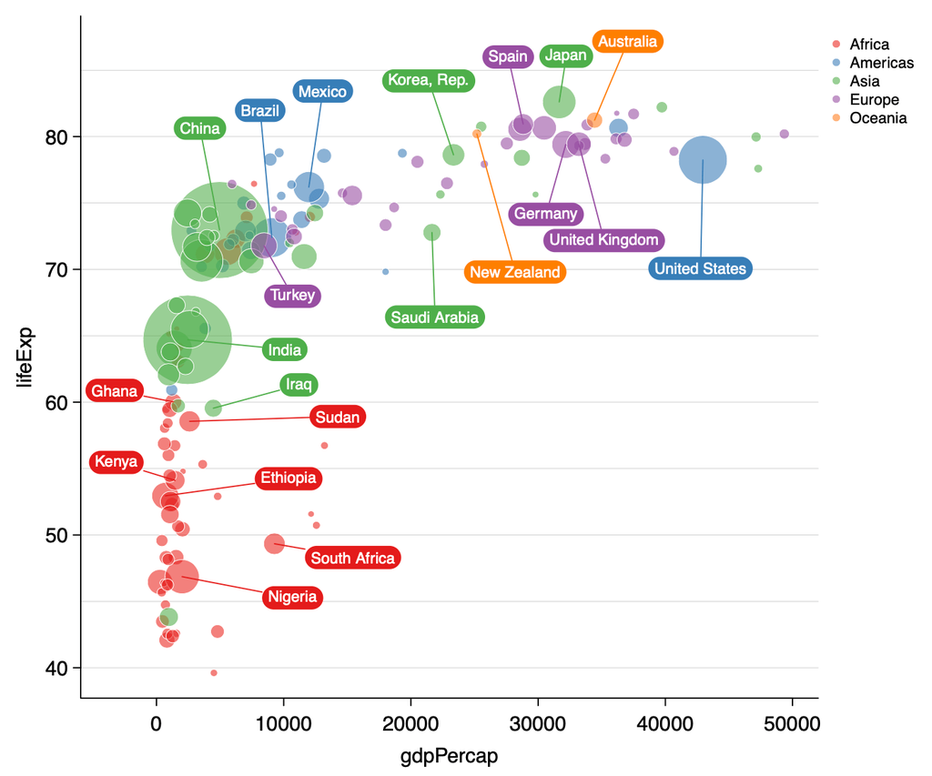

```r
# Rectangle fill colour and label line match point colours, rounded rectangles
easylabel(gapminder[gapminder$year == 2007, ], x = 'gdpPercap', y = 'lifeExp',
          col = 'continent', labs = 'country',
          size = 'pop',
          alpha = 0.6,
          line_col = "match", text_col = "white",
          rectangles = TRUE, border_col = NA,
          rect_col = "match", border_radius = 20, padding = 5,
          zeroline = FALSE, showgrid = "y")
```

# 6 Manhattan plot

Manhattan plots can be labelled using the function `easyManhattan()`. Plotly struggles with more than about 100,000 points, so we use a filtering system to reduce the number of points shown in the plotly interactive plot, while the full plot with all points is produced when saving to PDF. An example is shown below:

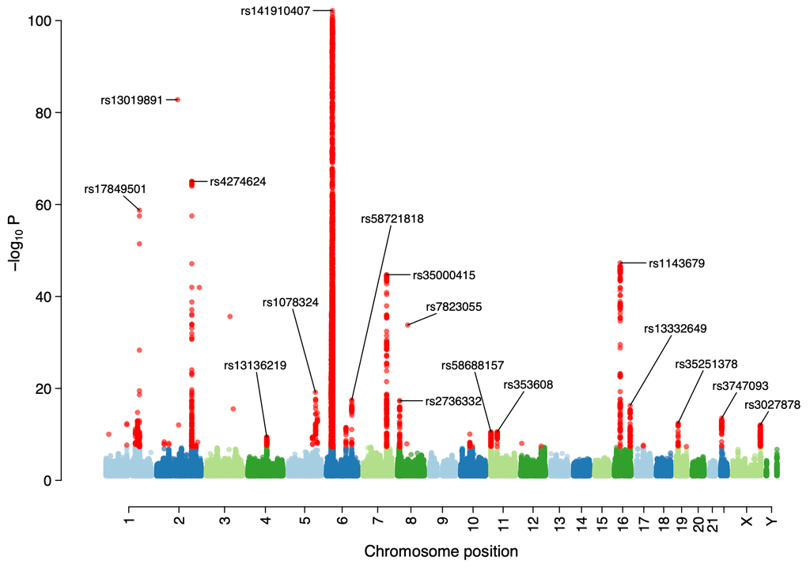

```r
# Manhattan plot using SLE GWAS data from Bentham et al 2015
# FTP download full summary statistics from
# https://www.ebi.ac.uk/gwas/studies/GCST003156
library(data.table)
SLE_gwas <- fread('../bentham_2015_26502338_sle_efo0002690_1_gwas.sumstats.tsv')
# Simple Manhattan plot
easyManhattan(SLE_gwas)

# 4 colours for chromosomes
easyManhattan(SLE_gwas, chromCols = RColorBrewer::brewer.pal(4, 'Paired'))
```

By default Manhattan plots display only the top 100,000 points by p value in the plotly window and plot the top 1 million SNPs when saving to PDF. These defaults can be altered by setting `npoints` and `nplotly`. Setting `npoints` to `NA` will plot all points when saving to PDF.

```r
# Examples
# 12 colours for chromosomes, no separate colour for significant points
easyManhattan(SLE_gwas, chromCols = RColorBrewer::brewer.pal(12, 'Paired'),
              sigCol = NA)

# Label peaks automatically, add horizontal gridlines
easyManhattan(SLE_gwas, npeaks = 20, showgrid = "y")

# Vertical version
easyManhattan(SLE_gwas, transpose = TRUE, height = 1000, width = 600)

# Chr1 only
easyManhattan(SLE_gwas[SLE_gwas$chrom == 1, ])

# Add symbols for the significant SNPs
easyManhattan(SLE_gwas, chromCols = RColorBrewer::brewer.pal(4, 'Paired'),
              size = 8,
              shape = 'col',
              shapeScheme = c(rep(20, 4), 18))
```

## 6.1 Locus plots

To look in a specific genomic region

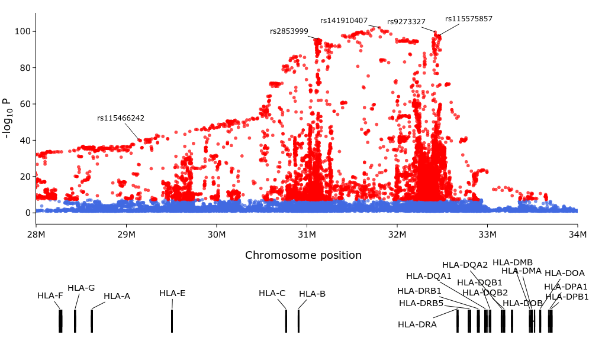

```r
# Create a locus plot over one chromosomal region
library(plotly)
p1 = easyManhattan(SLE_gwas[SLE_gwas$chrom == 6 &
                              SLE_gwas$pos >= 28e6 &
                              SLE_gwas$pos <= 34e6, ],
                   output_shiny = FALSE, labs = "rsid",
                   startLabels=c("rs115466242", "rs2853999"),
                   npeaks = 3)



# To annotate genes in that region
source("https://raw.githubusercontent.com/KatrionaGoldmann/BioOutputs/master/R/bio_gene_locations.R")
library(ggbio)
library(gginnards)
library(ggrepel)
if (! "EnsDb.Hsapiens.v75" %in% rownames(installed.packages()))
  BiocManager::install("EnsDb.Hsapiens.v75")

p2 = bio_gene_locations(6, c(28e6, 34e6),
                        subset_genes = c('HLA-F', 'HLA-G', 'HLA-A', 'HLA-E',
                                         'HLA-C', 'HLA-B', 'HLA-DRA',
                                         'HLA-DRB5', 'HLA-DRB1', 'HLA-DQA1',
                                         'HLA-DQB1', 'HLA-DQA2', 'HLA-DQB2',
                                         'HLA-DOB', 'HLA-DMB', 'HLA-DMA',
                                         'HLA-DOA', 'HLA-DPA1', 'HLA-DPB1'))

plotly::subplot(p1, p2$plotly_location %>% layout(yaxis=list(range=c(0.25, 2))),
                shareY = T, titleX = T, margin=0.05,
                nrows=2, heights=c(0.7, 0.3))
```

# 7 Known issues

- Plotly’s `scattergl` function, which uses webGL, seems to have a limit of around 400,000 scatter points per plot. Above this level, the shiny/plotly app becomes sluggish or freezes and becomes unusable. We recommend limiting plots to around 100,000 points using the `plotly_filter` argument. See plotly_filter.